# Basic probability, inference

Jeffrey Chrabaszcz  
6 January 2014

### Outline

1. Basics of probability
2. Probability distributions
3. Statistical inference
4. Classic confidence intervals
5. Classical hypothesis testing
6. Problems with *statistical significance*

### Basics of probability

## General

1. Definition of probability
   - \( P(A) + P(\neg A) = 1 \)
   - \( \sum\limits_{k = 1}^N P(x_k) = 1 \)
2. Intersection (AND, &)
   - \( P(A \cap B) = P(A) \cdot P(B) \)
3. Union (OR, |)
   - \( P(A \cup B) = P(A) + P(B) - P(A \cap B) \)
4. Conditional probability
   - \( P(A | B) = \frac{\displaystyle P(A \cap B)}{\displaystyle P(B)} \)

## Bayes' Rule

1. Definition
   - \( P(B | A) = \frac{\displaystyle P(A | B) \cdot P (B)}{\displaystyle P(A)} \)
2. Finite alternatives
   - \( P(H_i | D) = \frac{\displaystyle P(D | H_i) \cdot P (H_i)}{\displaystyle \sum\limits_{i=1}^N P(D | H_i)} \)

### AND, OR

```r
mean(juul$age[juul$sex == 1 & juul$tanner == 1], na.rm = TRUE)
```

```
[1] 8.05
```

```r
mean(juul$age[juul$sex == 1 | juul$tanner == 1], na.rm = TRUE)
```

```
[1] 13.5
```

### Many small random variables

```r
points <- rbinom(100, 1, .5)
head(points)
```

```
[1] 0 1 0 1 0 1
```

```r
sum(points)
```

```
[1] 44
```

```r
all.points <- matrix(rbinom(10000, 1, .5), ncol = 100)
```

```r
var(points)
```

```
[1] 0.249
```

```r
var(colSums(all.points))
```

```
[1] 26.7
```

```r
mean(colSums(all.points))
```

```
[1] 50
```

### Central limit theorem

Assuming the variance of the individual components is smaller than the aggregate score, (as in the last example), the **central limit theorem** holds.

\[ \lim_{n\to \infty} P\left(\frac{S_n - n\mu}{\sigma\sqrt{n}} \leq x\right) = \phi(x) \]

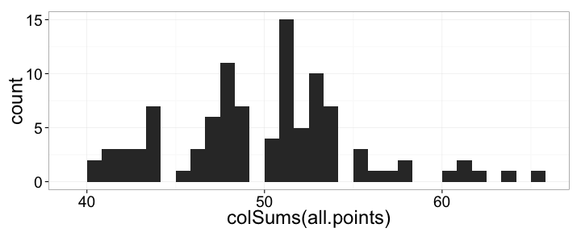

### Surprise! Calculus.

- Derivation, \( \frac{dy}{dx} \), is a rate of change. Think of it as the slope of a line.
- Integration, \( \int \), is the area under the curve.
- Summation, \( \sum \), is integration for discrete things.

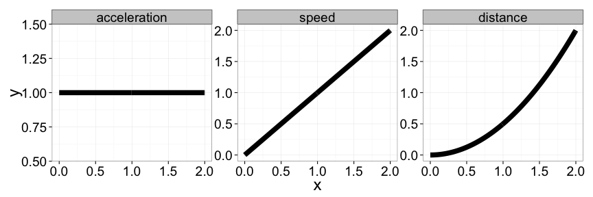

### Probability distributions

Probability distributions are special functions that **integrate to 1**. One example is a **normal distribution**, which has the following function:

\[ f(x) = \frac{1}{\sqrt{2\pi\sigma^2}}e^{-\frac{(x - \mu)^2}{2\sigma^2}} \]

The **standard normal** is defined as \( \mu = 0 \) and \( \sigma = 1 \).

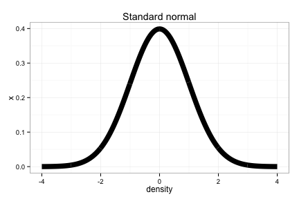

### Mean and variance

Expected value of the normal distribution is the mean:

\[ E[X] = \int_{-\infty}^{\infty} x \cdot f(x) dx \]

For a sample, we can't integrate:

\[ \bar{X} = \sum\limits_{i = 1}^N \frac{x_i}{N} \]

Knowing this, we can also get an estimate of spread:

\[ \sigma^{2}_x = \frac{\sum\limits_{i = 1}^N \left(x_i - \bar{x}\right)^2}{N - 1} \]

### Normals in R

Most standard probability distributions have a set of functions in R.

- density, d
- distribution, p
- quantile, q
- random deviates, r

Will also work for binomial, poisson, etc.

```r
pnorm(0)
```

```
[1] 0.5
```

```r
rnorm(10)
```

```
 [1] -1.058  2.318  0.137  0.179  0.761 -1.840 -0.362  0.761  0.418 -1.039
```

### Binomial

This distribution represents the number of times some binary event occurs when it has probability \( p \) and number of chances \( k \). Two parameters: \( n \) and \( k \).

\[ P(x = k) = {n \choose k}p^k(1 - p)^{n-k} \]

[figure not shown]

### Poisson

The probability of a number of events occuring in a given time period. Only one parameter, \( \lambda \).

\[ P(x = k) = \frac{\lambda^k e^{-k}}{k!} \]

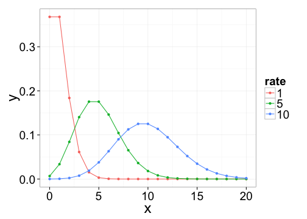

### Estimated regression coefficients

We'll get to the linear model tomorrow, but regression coefficients are ultimately normally distributed. This happens because regression weights are a linear combination of data. Formally:

\[ \beta = (X^tX)^{-1}X^ty \]

\[ y_i = \beta_0 + \beta_1 \cdot x_{1i} + \beta_2 \cdot x_{2i} + ... + \epsilon_i \]

This is important for later in the class! Parameters, just like data, can be subject to distributions.

### Statistical modeling

## sampling model

- data represent perfect observations of a small sample
- sample is representative of a population of interest
- goal is to learn about the population
- generally combined with measurement model

## measurement model

- data represent imperfect observations of a sample of interest
- sample is itself interesting, regardless of any superpopulation
- goal is to learn about sample despite measurement error

### Parameters and estimation

Statistical tests have a common goal: quantify uncertainty. Before we gather any data, we have some ideas about our outcome variable. Then we gather some data and we make some decisions:

- what did we know before we started?
- what did we learn from our experiment?
- how much have our beliefs changed and what do we know now?

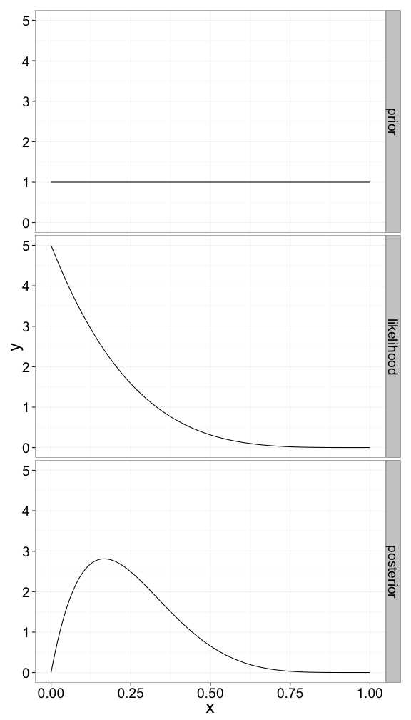

### Standard errors

\[ SEM = \sqrt{\frac{\sigma^2}{N}} \]

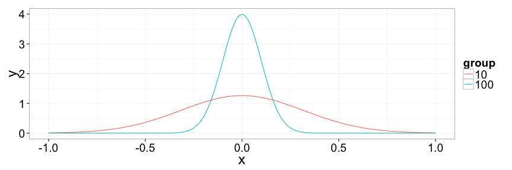

### Classical confidence intervals

```r
y <- c(35, 34, 38, 35, 37)
n <- length(y)
estimate <- mean(y)
se <- sd(y)/sqrt(n)
int.50 <- estimate + qt(c(.25, .75), n-1) * se
int.95 <- estimate + qt(c(.025, .975), n-1) * se
int.50
```

```
[1] 35.3 36.3
```

```r
int.95
```

```
[1] 33.8 37.8
```

### Confidence intervals for proportions

```r
y <- 700
n <- 1000
estimate <- y/n
se <- sqrt(estimate * (1 - estimate)/n)
int.95 <- estimate + qnorm(c(.025, .975)) * se
int.95
```

```
[1] 0.672 0.728
```

### Discrete data

```r
y <- rep(0:4, c(600, 300, 50, 30, 20))
n <- length(y)
estimate <- mean(y)
se <- sd(y)/sqrt(n)
int.50 <- estimate + qt(c(.25, .75), n-1) * se
int.50
```

```
[1] 0.551 0.589
```

### Numerical comparisons

Assume we have proportion of people improved by some treatment for two groups.

\[ \begin{array}{rcl} 80\% &\pm& 1.4\% \\ 74\% &\pm& 1.3\% \end{array} \]

Rather than explicitly comparing the groups, we can recast these quantities and examine the difference.

\[ \begin{array}{rcl} 80\% - 74\% &=& 6\% \\ \sqrt{(1.4\%)^2 + (1.3\%)^2} &=& 1.9\% \end{array} \]

### Visual comparisons

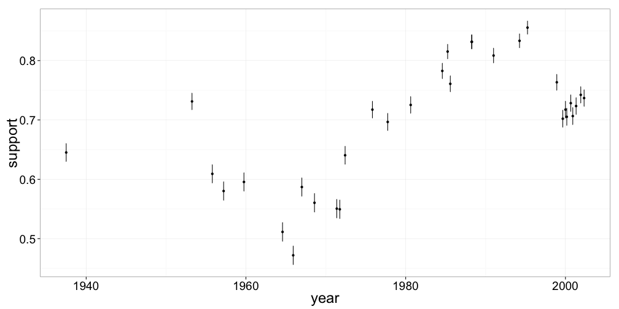

```r
qplot(year, support, data = a, geom = "errorbar", ymin = support - se, ymax = support + se) + geom_point(size = 2) + theme_bw(base_size = 24)
```

### Classical hypothesis testing

All NHST involves setting up a point null and testing the probability of observing your data given that the null is true.

\[ H_0: \mu_1 - \mu_2 = 0 \]

You can think of this like confidence intervals: if we say the difference is zero, we can then look at the observed difference and the 95% CI around the difference. If 0 is not in the CI, reject the null with (at least) a 5% false alarm rate.

### Problems with statistical significance

## statistical significance does not equal practical significance

\[ t = \frac{\bar{x}}{\sqrt{\frac{\sigma^2}{N}}} \]

## changes in significance are not themselves significant

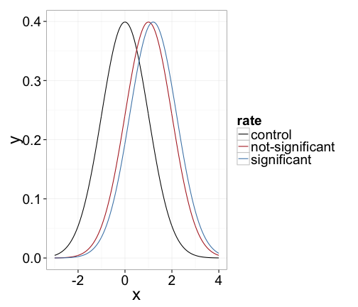